# Experimental Design and Differential Expression Analysis

Ricardo Ramirez

6/19/2019

#Designing Experiments

Your newly funded institute is ready and you have decided to produce massive omics data to understand cell mechanisms in cancer.

You are responsible of the NCI-60 cancer cell line panel!

You have treated different cancer cell lines (coming from different tissues) with different drugs.

1. Stop for a second… What can go wrong? Think of all the possible technical and experimental errors that may occur, from cell culture, omics profiling and team organization.
2. How many factors are you measuring in the NCI-60 panel? What are their levels?
3. Propose an experimental design to reduce technical variability and confounding factors.

# Exploring Batch Effects 1

You receive a new data set of gene expression that comprises 2 different disease conditions in the kidney (biopsies of different patients). The only meta information you have is the condition label. After plotting a MDS, you observe the following:

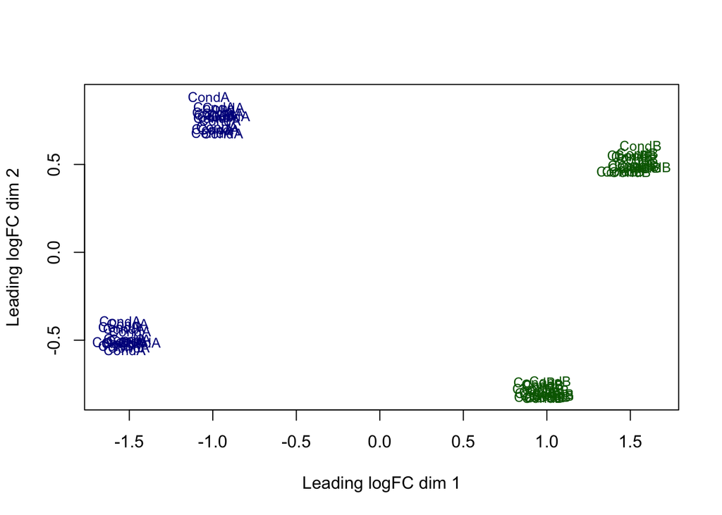

1. How do you explain this distribution of samples?

#Exploring Batch Effects 2

Your collaborator wants you to help him with a “simple” gene expression analysis of two different types of lung cancer.

You have meta information about who prepared the libraries for RNASeq and the conditions (data provided)

1. Plot a MDS or a PCA
2. What will you tell your collaborator? Is it a good idea to fit statistical models to this data set?
3. How would you plan this study?

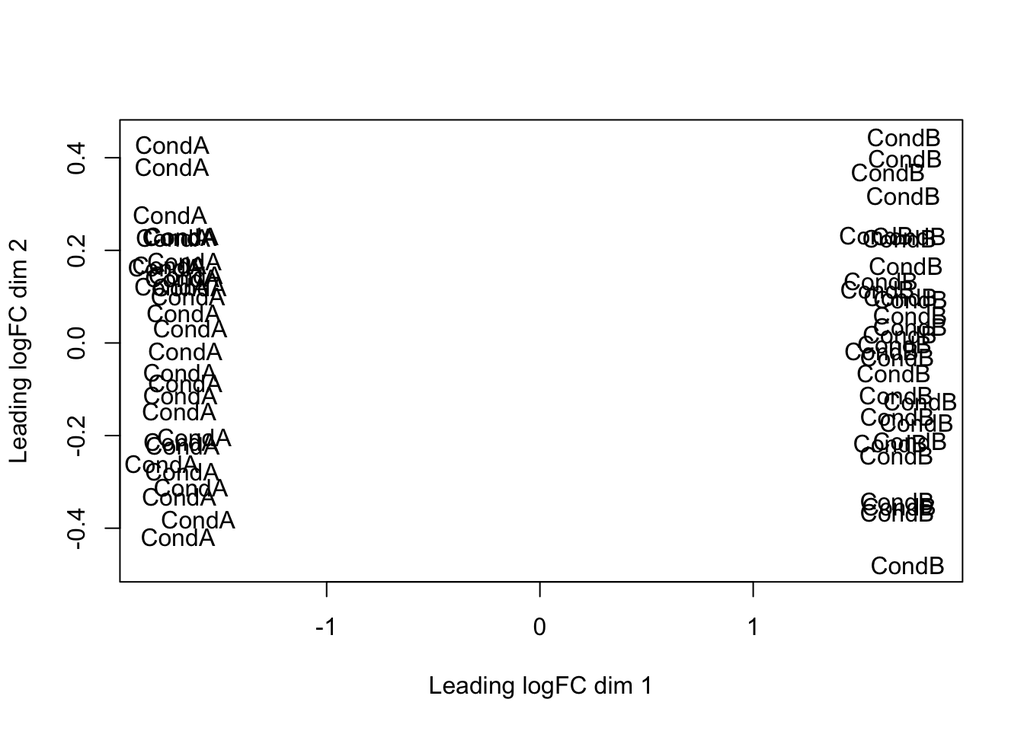

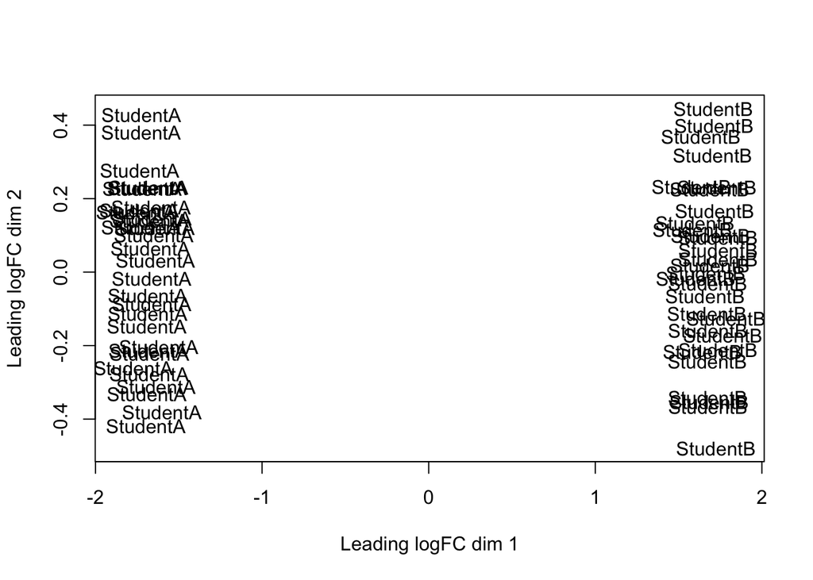

# Differential Expression NCI-60: Basics

1. Compare the basal expression profiles of two different tissues using the information coming of all cell lines
   - Make an exploratory analysis of the tissues you are using (barplot)
   - You can use linear models, t-test or anovas.
   - Compare the results with your classmates, the final results should all be the same (if filtered by p-value)

Read your data

```r
library(limma)
library(tidyverse)

data = as.matrix(read.csv('~/Dropbox/PhD/SysBioCourse/my_data.csv', row.names=1, stringsAsFactors=F))
meta = read.csv('~/Dropbox/PhD/SysBioCourse/my_p_data.csv', row.names=1, stringsAsFactors=F)
```

Let’s extract the information of our samples from the names

```r
METAdata = strsplit(meta$title,"_")
names(METAdata) = 1:length(METAdata)
METAdata = data.frame(t(bind_rows(METAdata)),
                      stringsAsFactors = F)
colnames(METAdata) = c("cell_line","drug","concentration","time")

METAdata$sample = meta$geo_accession
METAdata$tissue = meta$tissue.ch1
```

I will work with basal expression profiles

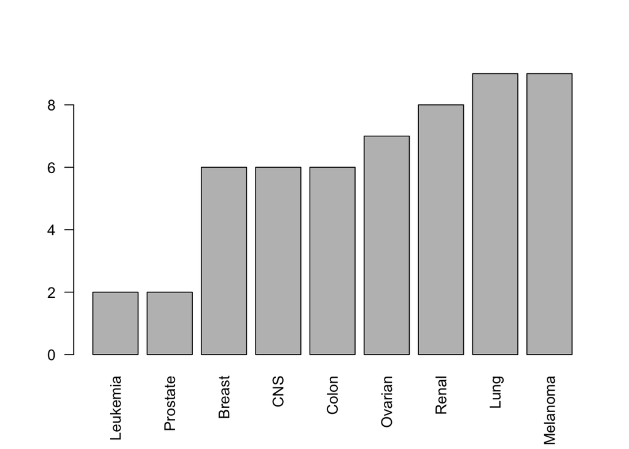

```r
basal_METAdata = filter(METAdata, concentration == "0nM")
basal_METAdata = METAdata[METAdata$concentration == "0nM",]

barplot(sort(table(basal_METAdata$tissue)),las =2)
```

Only choose two tissues

```r
basal_METAdata = filter(basal_METAdata, tissue %in% c("Renal","Lung"))
```

Get a reduced gene expression matrix

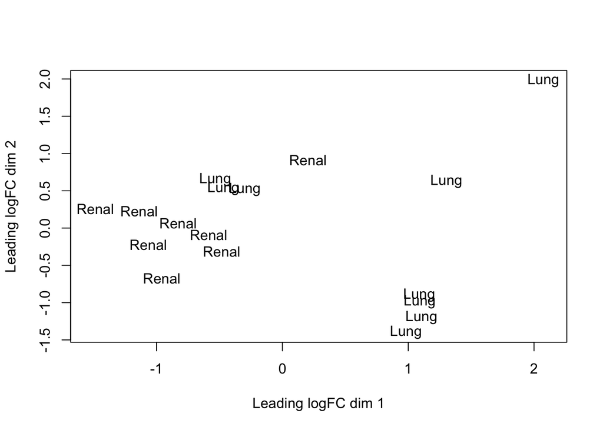

```r
basal_GEX = data[,basal_METAdata$sample]

plotMDS(basal_GEX,labels = basal_METAdata$tissue)
```

Let’s perform a Differential Expression Analysis using 3 different methods

```r
genes = rownames(basal_GEX)
names(genes) = genes


ttest_summary = data.frame(t(sapply(genes,function(gene){

       modelDF = tibble("Expression" = basal_GEX[gene,],
                        "Tissue" = factor(basal_METAdata$tissue,levels = c("Renal","Lung")))

       Renal_data = filter(modelDF,Tissue == "Renal")[[1]]
       Lung_data = filter(modelDF,Tissue == "Lung")[[1]]

       tres = t.test(Lung_data,Renal_data,var.equal = T)
       tres = c(tres$statistic,tres$p.value)
       names(tres) = c("t","p_value")

       return(tres)
})), stringsAsFactors = F) %>%
                rownames_to_column(var="Gene") %>% mutate("adj_pvalue" = p.adjust(p_value,"BH"))

ttest_genes = (filter(ttest_summary, adj_pvalue < 0.05))[[1]]

lm_summary = data.frame(t(sapply(genes,function(gene){

       modelDF = tibble("Expression" = basal_GEX[gene,],
                        "Tissue" = factor(basal_METAdata$tissue,levels = c("Renal","Lung")))

       lmres = lm(Expression~Tissue,data = modelDF)
       lmres = summary(lmres)$coefficients[2,c(3,4)]
       names(lmres) = c("t","p_value")

       return(lmres)
}))) %>% rownames_to_column(var="Gene") %>% mutate("adj_pvalue" = p.adjust(p_value,"BH"))

anova_summary = data.frame(t(sapply(genes,function(gene){

       modelDF = tibble("Expression" = basal_GEX[gene,],
                        "Tissue" = factor(basal_METAdata$tissue,levels = c("Renal","Lung")))

       anovares = anova(aov(Expression ~ Tissue,data = modelDF))
       anovares = c(anovares$`F value`[1],anovares$`Pr(>F)`[1])
       names(anovares) = c("F","p_value")

       return(anovares)
}))) %>% rownames_to_column(var="Gene") %>% mutate("adj_pvalue" = p.adjust(p_value,"BH"))
```

## Differential Expression NCI-60: Advanced

1. Repeat the last comparison using limma
2. Define a contrast

```r
Lung_Renal_data = basal_GEX[,basal_METAdata$sample]
f = factor(basal_METAdata$tissue, levels= c("Lung","Renal"))
design <- model.matrix(~0+f)
colnames(design) <- c("Lung","Renal")


fit <- lmFit(Lung_Renal_data, design) #Fit linear model, as before (intercept 0, so each coefficient is the mean)

cont.matrix <- makeContrasts(Tissue_dif = Lung - Renal,
                               levels=design)

fit2 <- contrasts.fit(fit, cont.matrix)
fit2 <- eBayes(fit2)

DEA_results = as.data.frame(topTable(fit2,adjust.method = "BH",number = Inf)) %>% rownames_to_column(var = "Gene") %>%
               arrange(desc(abs(t))) %>% as_tibble()

limma_genes = filter(DEA_results, adj.P.Val < 0.05)[[1]]

DEA_results
```

```
## # A tibble: 12,984 x 7
##    Gene      logFC AveExpr     t      P.Value adj.P.Val     B
##    <chr>     <dbl>   <dbl> <dbl>        <dbl>     <dbl> <dbl>
##  1 APBB1IP  -2.00     4.91 -9.67 0.0000000268  0.000348  8.12
##  2 PAX8     -2.50     5.38 -7.36 0.00000115    0.00747   5.23
##  3 RALGAPA1  0.914    5.77  6.62 0.00000447    0.0194    4.11
##  4 MOXD1    -3.68     6.87 -6.02 0.0000142     0.0425    3.13
##  5 CNIH1     0.752   10.8   5.86 0.0000194     0.0425    2.87
##  6 GFRA1    -2.75     5.31 -5.85 0.0000196     0.0425    2.86
##  7 HOXA10   -3.04     6.56 -5.69 0.0000270     0.0500    2.58
##  8 PLK2     -2.39    10.1  -5.60 0.0000329     0.0500    2.41
##  9 PTPN13   -2.17     7.01 -5.47 0.0000427     0.0500    2.19
## 10 FAM49A   -2.68     4.96 -5.43 0.0000460     0.0500    2.12
## # … with 12,974 more rows
```